# R Notebook

```r
library(here)
library(janitor)
library(stringr)
library(readxl)
library(fastICA)
library(tidyverse)
```

Rutas

```r
raw_data <- here("data", "raw")
interim_data <- here("data", "interim")
processed_data <- here("data", "processed")
```

Cargando datos

```r
datos = readRDS(paste0(processed_data, "/datos_tasa.Rds"))
datos_eda = readRDS(paste0(processed_data, "/datos_tasa_EDA.Rds"))

head(datos)
```

| semana_rango | fecha | semana | mes | trimestre | anno | 1 | 2 | 3 | 4 | 5 | 6 | 7 | 8 | 9 | 10 | 11 | 12 | 13 | 14 | 15 | 16 | 17 | 18 | 19 | 20 | 21 | 22 | 23 | 24 | … |
| --- | --- | --- | --- | --- | --- | --- | --- | --- | --- | --- | --- | --- | --- | --- | --- | --- | --- | --- | --- | --- | --- | --- | --- | --- | --- | --- | --- | --- | --- | --- |
| 14-12-16 al 20-12-16 | 2016-12-20 | 51 | 12 | 4 | 2016 | 0.75 | 0.7910287 | 0.8114165 | 0.8317203 | 0.8519405 | 0.8720775 | 0.8921315 | 0.912103 | 0.9319922 | 0.9517995 | 0.9715252 | 0.9911697 | 1.010733 | 1.030216 | 1.049619 | 1.068942 | 1.088185 | 1.107349 | 1.126433 | 1.14544 | 1.164368 | 1.183218 | 1.20199 | 1.220685 | … |
| 07-12-16 al 13-12-16 | 2016-12-13 | 50 | 12 | 4 | 2016 | 0.75 | 0.7950000 | 0.8170000 | 0.8390000 | 0.8610000 | 0.8820000 | 0.9040000 | 0.926000 | 0.9470000 | 0.9690000 | 0.9900000 | 1.0110000 | 1.032000 | 1.053000 | 1.074000 | 1.095000 | 1.116000 | 1.137000 | 1.157000 | 1.17800 | 1.198000 | 1.218000 | 1.23800 | 1.258000 | … |
| 30-11-16 al 06-12-16 | 2016-12-06 | 49 | 12 | 4 | 2016 | 0.75 | 0.7880000 | 0.8070000 | 0.8250000 | 0.8440000 | 0.8630000 | 0.8810000 | 0.900000 | 0.9180000 | 0.9370000 | 0.9550000 | 0.9730000 | 0.991000 | 1.010000 | 1.028000 | 1.046000 | 1.063000 | 1.081000 | 1.099000 | 1.11700 | 1.135000 | 1.152000 | 1.17000 | 1.187000 | … |
| 23-11-16 al 29-11-16 | 2016-11-29 | 48 | 11 | 4 | 2016 | 0.75 | 0.7940000 | 0.8160000 | 0.8380000 | 0.8600000 | 0.8820000 | 0.9030000 | 0.925000 | 0.9460000 | 0.9680000 | 0.9890000 | 1.0100000 | 1.031000 | 1.052000 | 1.072000 | 1.093000 | 1.114000 | 1.134000 | 1.155000 | 1.17500 | 1.195000 | 1.215000 | 1.23500 | 1.255000 | … |
| 16-11-16 al 22-11-16 | 2016-11-22 | 47 | 11 | 4 | 2016 | 0.75 | 0.7870000 | 0.8060000 | 0.8240000 | 0.8420000 | 0.8610000 | 0.8790000 | 0.897000 | 0.9150000 | 0.9330000 | 0.9510000 | 0.9690000 | 0.987000 | 1.005000 | 1.022000 | 1.040000 | 1.057000 | 1.075000 | 1.092000 | 1.11000 | 1.127000 | 1.144000 | 1.16200 | 1.179000 | … |
| 09-11-16 al 15-11-16 | 2016-11-15 | 46 | 11 | 4 | 2016 | 0.75 | 0.7850000 | 0.8020000 | 0.8190000 | 0.8360000 | 0.8530000 | 0.8700000 | 0.887000 | 0.9040000 | 0.9200000 | 0.9370000 | 0.9540000 | 0.971000 | 0.987000 | 1.004000 | 1.020000 | 1.036000 | 1.053000 | 1.069000 | 1.08500 | 1.101000 | 1.117000 | 1.13400 | 1.150000 | … |

# Reduccion

## PCA

### Calculo del modelo

```r
datos_pca <- datos %>%
  select("1":"3600")

prin_comp <- prcomp(datos_pca, scale. = T)
```

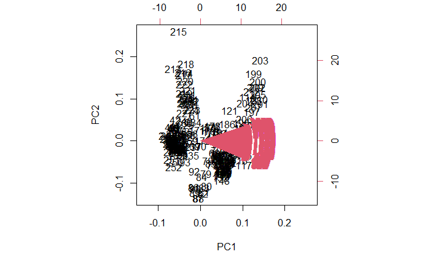

```r
biplot(prin_comp)
```

### Valores propios

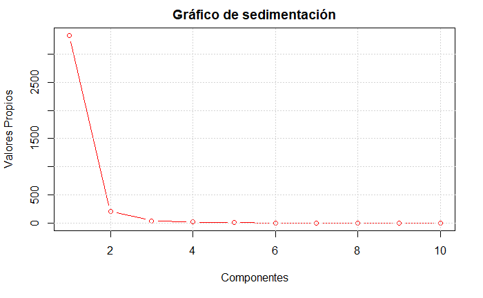

```r
#standard deviation
std_dev <- prin_comp$sdev

#variance / valores propios
pr_var <- std_dev^2

plot(pr_var[1:10],
     main = "Gráfico de sedimentación",
     type = "b",
     col = "red",
     ylab="Valores Propios",
     xlab = "Componentes")
grid()
```

Según el gráfico de sedimentación se podrían sugerir 2 o 3 componentes.

### Variabilidad explicada

```r
#proportion of variance explained
prop_varex <- pr_var/sum(pr_var)

#summary(prin_comp)

df_sum<-data.frame(Componente=c(1:10),
                   valores_propios=round(pr_var[1:10],1),
                   porc_explicado= round(prop_varex[1:10]*100,1),
                   porc_acum= cumsum(round(prop_varex[1:10]*100,1))
                   )
df_sum
```

| Componente | valores_propios | porc_explicado | porc_acum |
| --- | --- | --- | --- |
| 1 | 3337.8 | 92.7 | 92.7 |
| 2 | 202.2 | 5.6 | 98.3 |
| 3 | 38.9 | 1.1 | 99.4 |
| 4 | 15.5 | 0.4 | 99.8 |
| 5 | 3.6 | 0.1 | 99.9 |
| 6 | 1.2 | 0.0 | 99.9 |
| 7 | 0.5 | 0.0 | 99.9 |
| 8 | 0.1 | 0.0 | 99.9 |
| 9 | 0.0 | 0.0 | 99.9 |
| 10 | 0.0 | 0.0 | 99.9 |

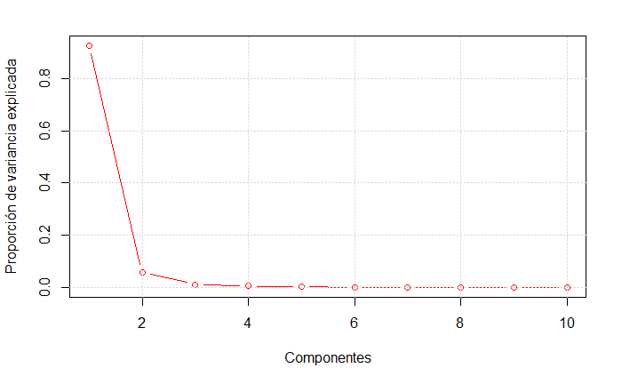

```r
#scree plot
plot(prop_varex[1:10], xlab = "Componentes",
             ylab = "Proporción de variancia explicada",
             type = "b",
              col = "red")
grid()
```

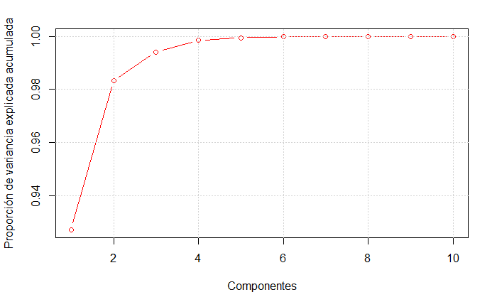

```r
#cumulative scree plot
plot(cumsum(prop_varex[1:10]), xlab = "Componentes",
              ylab = "Proporción de variancia explicada acumulada",
              type = "b",
              col = "red")
grid()
```

Se puede apreciar que el primer componente explica el 92.7%, el segundo el 5.6% y el tercero el 1.1%, en conjunto los tres primeros componentes principales explican el 99.4% de la variancia total. El nivel y la pendiente tienen la mayor participación en la explicación de la variabilidad. El 98.3% de la variancia total de los datos se explica a partir de los desplazamientos paralelos y de la pendiente de la curva, mientras que la curvatura explica sólo el 1.1% de los movimientos.

### Correlacion entre datos y componentes

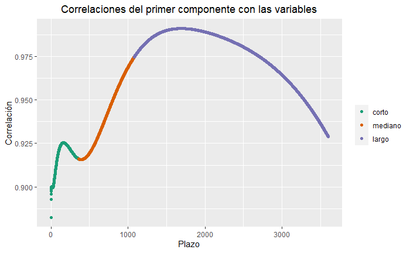

```r
cor_pca = cor(datos_pca, prin_comp$x)


tibble(dias = 1:3600,
      plazo = factor(c(rep("corto", 360),
                 rep("mediano", 720),
                 rep("largo", 2520)),levels=c("corto","mediano","largo")),
       correlacion = cor_pca[,1]
       ) %>%
  ggplot(aes(x = dias, y = correlacion, color = plazo))+
  geom_point()+
  scale_color_brewer(palette = "Dark2") +
  theme(legend.title = element_blank(),
        plot.title = element_text(hjust = 0.5)) +
  ylab("Correlación") +
  xlab("Plazo") +
  ggtitle("Correlaciones del primer componente con las variables")
```

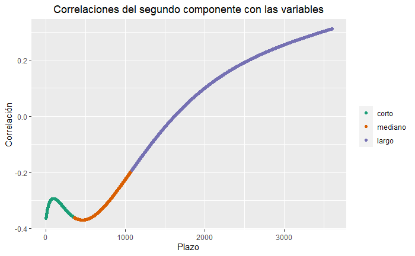

```r
tibble(dias = 1:3600,
      plazo = factor(c(rep("corto", 360),
                 rep("mediano", 720),
                 rep("largo", 2520)),levels=c("corto","mediano","largo")),
       correlacion = cor_pca[,2]
       ) %>%
  ggplot(aes(x = dias, y = correlacion, color = plazo))+
  geom_point()+
  scale_color_brewer(palette = "Dark2") +
  theme(legend.title = element_blank(),
        plot.title = element_text(hjust = 0.5)) +
  ylab("Correlación") +
  xlab("Plazo") +
  ggtitle("Correlaciones del segundo componente con las variables")
```

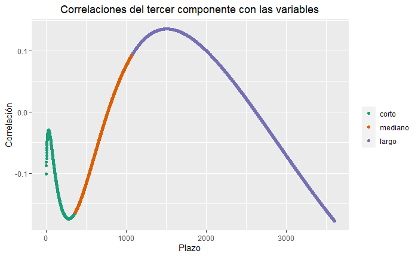

```r
tibble(dias = 1:3600,
      plazo = factor(c(rep("corto", 360),
                 rep("mediano", 720),
                 rep("largo", 2520)),levels=c("corto","mediano","largo")),
       correlacion = cor_pca[,3]
       ) %>%
  ggplot(aes(x = dias, y = correlacion, color = plazo))+
  geom_point()+
  scale_color_brewer(palette = "Dark2") +
  theme(legend.title = element_blank(),
        plot.title = element_text(hjust = 0.5)) +
  ylab("Correlación") +
  xlab("Plazo") +
  ggtitle("Correlaciones del tercer componente con las variables")
```

### Vectores propios

```r
vectores_prop<-prin_comp$rotation
head(vectores_prop[,1:10])
```

```
         PC1         PC2         PC3           PC4         PC5         PC6       PC7
1 0.01527380 -0.02553323 -0.01619346 -0.0134663917 -0.04640419 -0.06386599 0.2811732
2 0.01545503 -0.02550604 -0.01409044  0.0002569798 -0.05930827 -0.08933509 0.2479491
3 0.01550383 -0.02538560 -0.01312910  0.0062778807 -0.06429186 -0.09898120 0.2300692
4 0.01553499 -0.02524946 -0.01222018  0.0116049491 -0.06823733 -0.10592855 0.2121723
5 0.01555497 -0.02511155 -0.01138465  0.0163090046 -0.07140965 -0.11074172 0.1948171
6 0.01556806 -0.02497244 -0.01062624  0.0205106297 -0.07399231 -0.11396531 0.1782018
        PC8         PC9        PC10
1 0.2836664 -0.44969030 -0.44110649
2 0.2297147 -0.23513017 -0.15948882
3 0.2022625 -0.14436087 -0.05078534
4 0.1758669 -0.07447305  0.02412299
5 0.1511713 -0.02177932  0.07240594
6 0.1284099  0.01727128  0.10129335
```

- Primer Componente (Nivel)

las cargas del primer componente principal son todas positivas y similares entre sí. En nuestro caso este factor explica un 92.7%, de la variabilidad total, siendo claramente el más importante. El primer factor es casi plano.

```r
pl<-c(rep("seagreen",360),rep("darkorange3",720),rep("mediumpurple3",2520))

plot(vectores_prop[,1],
     ylim = c(0.01,0.02),
     xlab = "Plazo",
     ylab = "Carga Componente 1",
     col=pl,
     main = "Vectores propios - primer componente")
legend("bottomright",legend = c("corto","mediano","largo"), col = c("seagreen","darkorange3","mediumpurple3"),bty="n" ,lty = 1, lwd = 1)
```

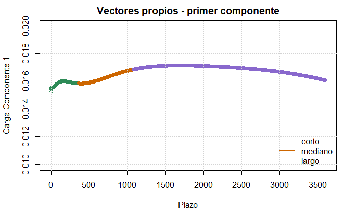

```r
grid()
```

- Segundo Componente (pendiente)

Para los vencimientos a corto plazo prevalecen los valores negativos y para los vencimientos a largo plazo las cargas son positivas, signos opuestos en ambos extremos. Este factor contribuye a explicar la variabilidad de las tasas en un 5.6%

```r
plot(vectores_prop[,2],
     xlab = "Plazo",
     ylab = "Carga Componente 2",
     col=pl,
     main = "Vectores propios - segundo componente")
legend("bottomright",legend = c("corto","mediano","largo"), col = c("seagreen","darkorange3","mediumpurple3"),bty="n" ,lty = 1, lwd = 1)
```

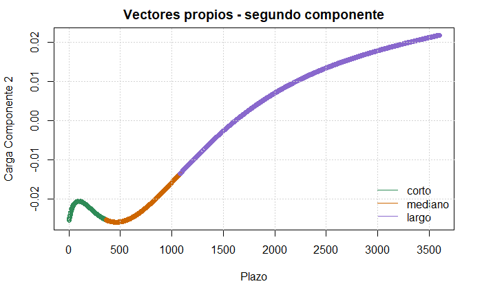

```r
grid()
```

- Tercer Componente (curvatura)

El tercer componente, contribuye a la variabilidad total en un 1.1% y se le asocia a cambios en la concavidad de la curva. Signo contrario en el centro que el de los extremos.

```r
plot(vectores_prop[,3],
     xlab = "Plazo",
     ylab = "Carga Componente 3",
     col=pl,
     main = "Vectores propios - tercer componente")
legend("topright",legend = c("corto","mediano","largo"), col = c("seagreen","darkorange3","mediumpurple3"),bty="n" ,lty = 1, lwd = 1)
```

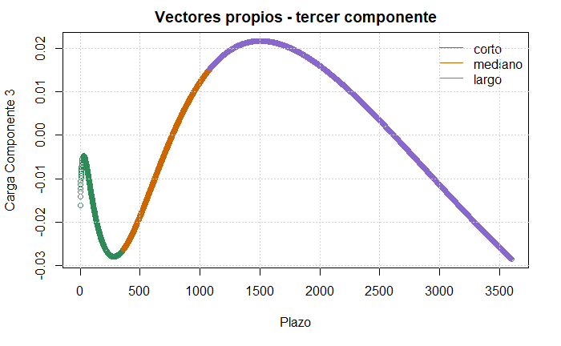

```r
grid()
```

```r
plot(vectores_prop[,2],
     xlab = "Plazo",
     ylab = "Carga",
     col="red",
     main = "Vectores propios - primeros tres componentes",
     type = "l",
     ylim = c(-0.03,0.06)
     )

points(vectores_prop[,3],col="green",type = "l")
```

```r
points(vectores_prop[,1],col="blue",type = "l")
abline(v=360,col="gray",lty=2)
```

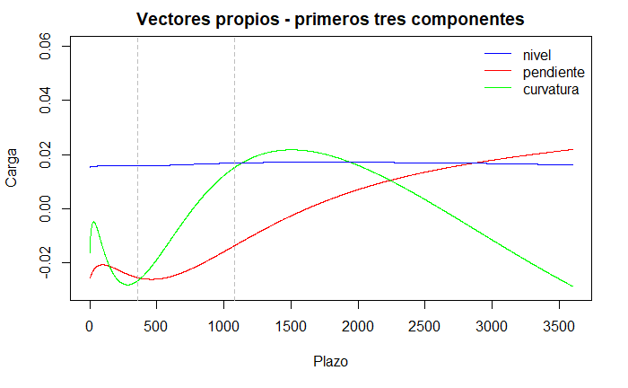

```r
abline(v=1080,col="gray",lty=2)
legend("topright",legend = c("nivel","pendiente","curvatura"), col = c("blue","red","green"),bty="n" ,lty = 1, lwd = 1)
```